# TFG - Técnicas Multivariantes de Clasificación y su Aplicación para la Identificación de Sucesos de Tipo Cuasielástico en el Experimento SBND

José Antonio Rosano Calvillo

2024-05-12

# 1 Preparación de los datos

## 1.1 Instalación de paquetes de R. Lectura de datos

```r
# Paquetes a usar
library(summarytools) # Permite llamar a 'freq' y 'descr'
library(ggplot2) # Permite llamar a 'ggplot'
library(ggpubr) # Permite llamar a 'ggarrange'
library(tidyverse) # Permite trabajar con las tuberías %>%
library(ICSNP) # Permite llamar a 'HotellingsT2'
library(caret) # Permite llamar a 'createDataPartition'
library(reshape2) # Permite llamar a 'melt'
library(MVN) # Permite llamar a 'mvn'
library(psych) # Permite llamar a 'cortest.bartlett'
library(biotools) # Permite llamar a 'boxM'
library("pROC") # Permite llamar a 'roc'
library(naivebayes) # Permite llamar a 'naive_bayes'
library(class) # Permite llamar a 'knn'

# Lectura de datos
datos<-read.csv("data_QE.csv", header = TRUE,sep =",")
```

## 1.2 Variables `QE` y `var_nuevosuc`

```r
attach(datos)

# Se crea nueva variable de "datos" que marque si el suceso es señal o fondo
QE = c()
QE[(nuPDG_truth==14 | nuPDG_truth==-14) & ccnc_truth==0 & mode_truth==0] = "Señal"
QE[(nuPDG_truth!=14 & nuPDG_truth!=-14) | ccnc_truth!=0 | mode_truth!=0] = "Fondo"

# Se crea nueva variable de "datos" que marque si el suceso es nuevo (eventID distinto)
var_nuevosuc = !duplicated(eventID)

# Se integran las variables recodificadas en el dataframe
datos$QE=QE
datos$var_nuevosuc=var_nuevosuc

detach(datos)
```

## 1.3 SubDataframe de `datos`

```r
datos_red <- subset(datos, var_nuevosuc==TRUE, c(eventID:nShowers,QE,var_nuevosuc))
```

## 1.4 Variables `maxtrack` y `maxshower`

```r
# Se crea nueva variable de "datos_red" que marque el máximo de "trcklength"
aux <- datos %>%
  group_by(eventID) %>%
  summarise(maxtrack = max(trcklength))

aux$maxtrack[aux$maxtrack == -1] = 0 # Cambiar los -1 por 0
datos_red$maxtrack=aux$maxtrack # Añadir a datos_red

# Se crea nueva variable de "datos_red" que marque el máximo de "shwlength"
aux <- datos %>%
  group_by(eventID) %>%
  summarise(maxshower = max(shwlength))

aux$maxshower[aux$maxshower == -1] = 0 # Cambiar los -1 por 0
datos_red$maxshower=aux$maxshower # Añadir a datos_red
```

## 1.5 Selección de Variables

```r
# Selección de variables tras estudio previo.
# Quito los (0,0,0), cuya topología no ha podido reconstruirse y los nTracks == 0
dat <- subset(datos_red, (nVertices + nTracks + nShowers != 0) & (nTracks!=0),
              c(9,10,13,14,7,11))

# Agrupo los valores menos frecuentes de las variables discretas
aux<- (dat[,1]==0)*(0)+(dat[,1]==1)*(1)+(dat[,1]==2)*(2)+(dat[,1]==3)*(3)+(dat[,1]>3)*(4)
dat$nTracks <- aux

aux<- (dat[,2]==0)*(0)+(dat[,2]==1)*(1)+(dat[,2]==2)*(2)+(dat[,2]==3)*(3)+
  (dat[,2]>3)*(4)
dat$nShowers <- aux

# Creo data frames solo de señal y de fondo
dat.QE <- split(dat,dat$QE)
```

# 2 Análisis Exploratorio de los Datos

## 2.1 Número de sucesos `Señal` y `Fondo`

```r
# En la muestra total (train.set + test.set):
freq(dat$QE)
```

```
## Frequencies
## dat$QE
## Type: Character
##
##                Freq   % Valid   % Valid Cum.   % Total   % Total Cum.
## ----------- ------- --------- -------------- --------- --------------
##       Fondo   41527     58.40          58.40     58.40          58.40
##       Señal   29580     41.60         100.00     41.60         100.00
##        <NA>       0                               0.00         100.00
##       Total   71107    100.00         100.00    100.00         100.00
```

## 2.2 Número de NAs

```r
# En la muestra total (train.set + test.set):
colSums(is.na(dat[-6]))
```

```
##   nTracks  nShowers  maxtrack maxshower     nHits
##         0         0         0         0         0
```

## 2.3 Variable ´nTracks´

```r
# Tabla de frecuencias
freq(dat$nTracks)
```

```
## Frequencies
## dat$nTracks
## Type: Numeric
##
##                Freq   % Valid   % Valid Cum.   % Total   % Total Cum.
## ----------- ------- --------- -------------- --------- --------------
##           1   36474     51.29          51.29     51.29          51.29
##           2   26009     36.58          87.87     36.58          87.87
##           3    6655      9.36          97.23      9.36          97.23
##           4    1969      2.77         100.00      2.77         100.00
##        <NA>       0                               0.00         100.00
##       Total   71107    100.00         100.00    100.00         100.00
```

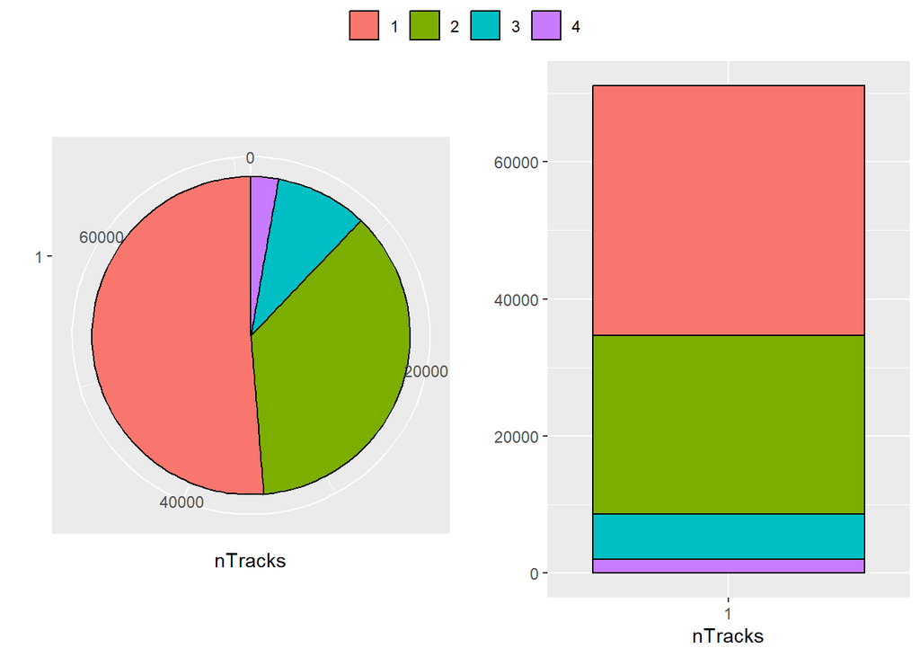

```r
# Gráfico circular y de barras
p1<-ggplot(dat,aes(x=factor(1),fill=factor(dat$nTracks)))+
  geom_bar(color="black")+coord_polar("y")+labs(x="",y="nTracks")+
  theme(legend.title = element_blank())
p2<-ggplot(dat,aes(x=factor(1),fill=factor(dat$nTracks)))+
  geom_bar(color="black")+labs(x="nTracks",y="")

ggarrange(p1,p2,nrow = 1,ncol=2, common.legend = TRUE)
```

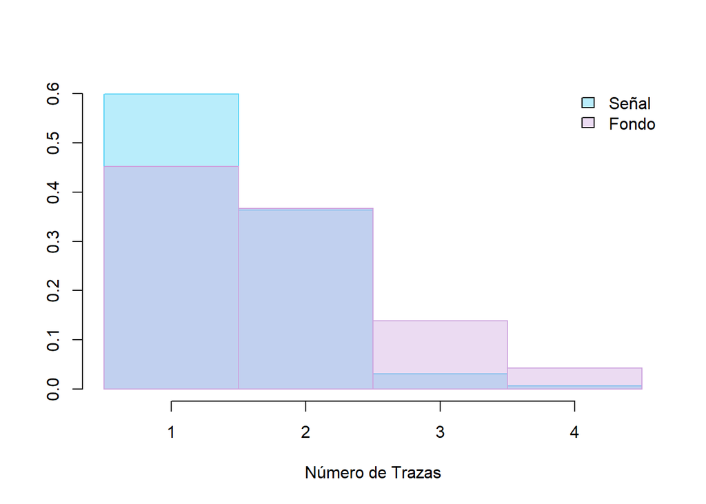

```r
# Histogramas, separando señal y fondo
x <- dat.QE$Señal$nTracks
p1 <- hist(x, breaks = seq(min(x)-1/2,max(x)+1/2), freq=FALSE, col="#51d1f666", border = "#51d1f6", main = "", xlab = "Número de Trazas", ylab = "")
legend("topright", legend=c("Señal","Fondo"), box.col = "white",  fill=c("#51d1f666","#cda4de66"))

y <- dat.QE$Fondo$nTracks
p2 <- hist(y, breaks = seq(min(y)-1/2,max(y)+1/2), freq=FALSE, col="#cda4de66", border = "#cda4de", add = TRUE)
```

## 2.4 Variable ´nShowers´

```r
# Tabla de frecuencias
freq(dat$nShowers)
```

```
## Frequencies
## dat$nShowers
## Type: Numeric
##
##                Freq   % Valid   % Valid Cum.   % Total   % Total Cum.
## ----------- ------- --------- -------------- --------- --------------
##           0   30114     42.35          42.35     42.35          42.35
##           1   22227     31.26          73.61     31.26          73.61
##           2   10772     15.15          88.76     15.15          88.76
##           3    4617      6.49          95.25      6.49          95.25
##           4    3377      4.75         100.00      4.75         100.00
##        <NA>       0                               0.00         100.00
##       Total   71107    100.00         100.00    100.00         100.00
```

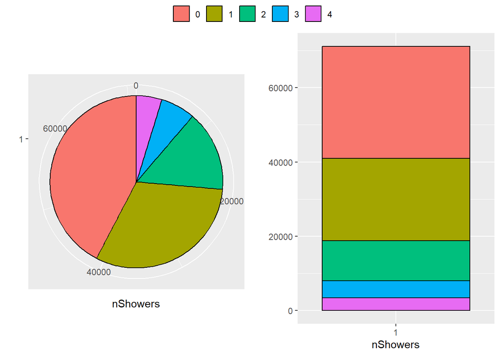

```r
# Gráfico circular y de barras
p1<-ggplot(dat,aes(x=factor(1),fill=factor(dat$nShowers)))+
  geom_bar(color="black")+coord_polar("y")+labs(x="",y="nShowers")+
  theme(legend.title = element_blank())
p2<-ggplot(dat,aes(x=factor(1),fill=factor(dat$nShowers)))+
  geom_bar(color="black")+labs(x="nShowers",y="")

ggarrange(p1,p2,nrow = 1,ncol=2, common.legend = TRUE)
```

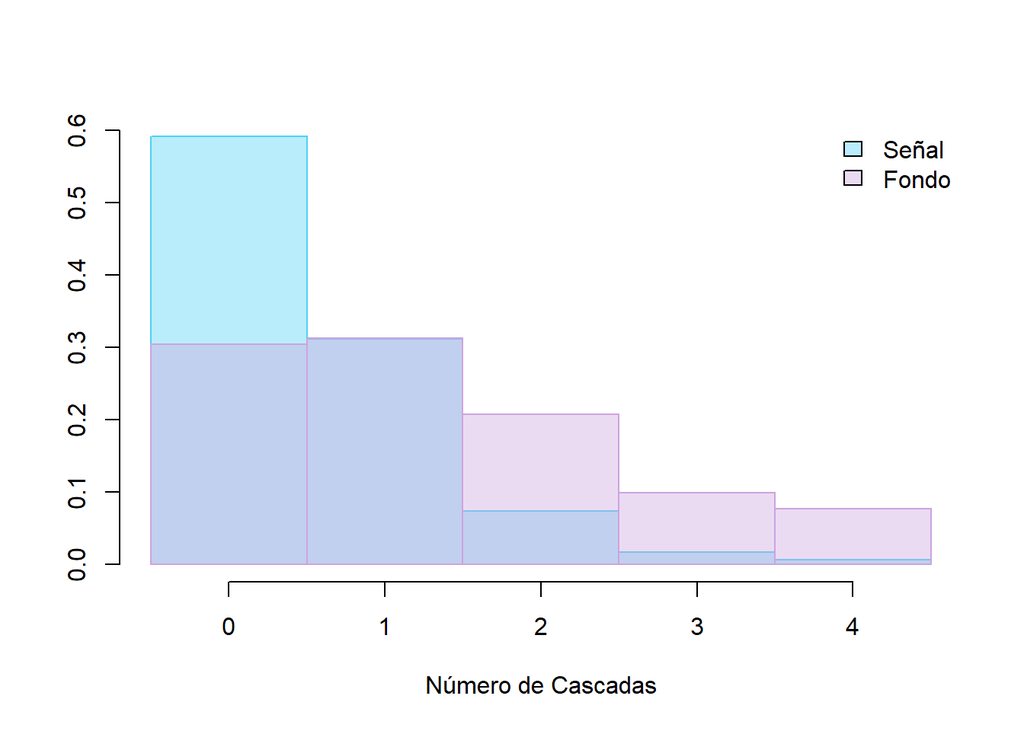

```r
# Histogramas, separando señal y fondo
x <- dat.QE$Señal$nShowers
p1 <- hist(x, breaks = seq(min(x)-1/2,max(x)+1/2), freq=FALSE, col="#51d1f666", border = "#51d1f6", main = "", xlab = "Número de Cascadas", ylab = "")
legend("topright", legend=c("Señal","Fondo"), box.col = "white",  fill=c("#51d1f666","#cda4de66"))

y <- dat.QE$Fondo$nShowers
p2 <- hist(y, breaks = seq(min(y)-1/2,max(y)+1/2), freq=FALSE, col="#cda4de66", border = "#cda4de", add = TRUE)
```

## 2.5 Variable `maxtrack`

```r
descr(dat$maxtrack)
```

```
## Descriptive Statistics
## dat$maxtrack
## N: 71107
##
##                     maxtrack
## ----------------- ----------
##              Mean     115.23
##           Std.Dev     100.72
##               Min       0.28
##                Q1      39.29
##            Median      87.64
##                Q3     164.42
##               Max    3529.34
##               MAD      83.96
##               IQR     125.12
##                CV       0.87
##          Skewness       2.23
##       SE.Skewness       0.01
##          Kurtosis      28.77
##           N.Valid   71107.00
##         Pct.Valid     100.00
```

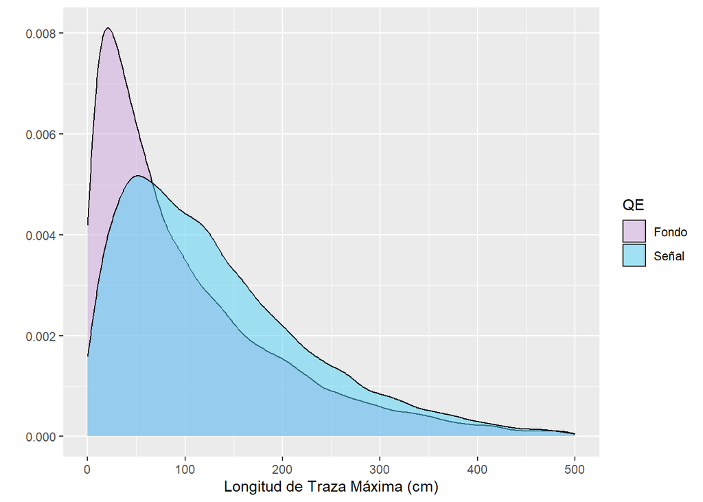

```r
ggplot(data = dat, aes(x = maxtrack, fill = QE)) +
      geom_density(alpha = 0.5) + scale_fill_manual(values = c("#cda4de66", "#51d1f666")) +
      labs(x="Longitud de Traza Máxima (cm)", y="") + xlim(0,500)
```

## 2.6 Variable `maxshower`

```r
descr(dat$maxshower)
```

```
## Descriptive Statistics
## dat$maxshower
## N: 71107
##
##                     maxshower
## ----------------- -----------
##              Mean       18.90
##           Std.Dev       36.19
##               Min        0.00
##                Q1        0.00
##            Median        5.52
##                Q3       21.31
##               Max      507.98
##               MAD        8.19
##               IQR       21.31
##                CV        1.91
##          Skewness        3.78
##       SE.Skewness        0.01
##          Kurtosis       18.85
##           N.Valid    71107.00
##         Pct.Valid      100.00
```

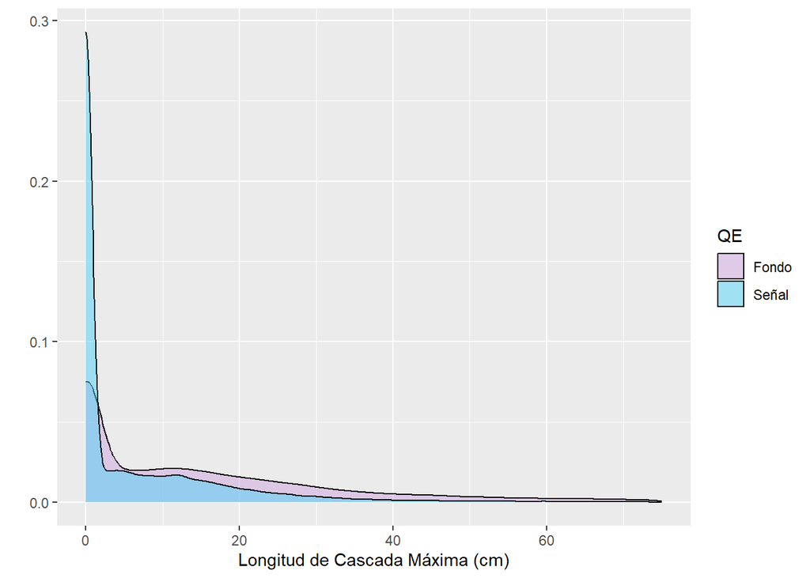

```r
p2 <- ggplot(data = dat, aes(x = maxshower, fill = QE)) +
      geom_density(alpha = 0.5) + scale_fill_manual(values = c("#cda4de66", "#51d1f666")) +
      labs(x="Longitud de Cascada Máxima (cm)", y="") + xlim(0,75)
p2
```

```r
#ggarrange(p1,p2, nrow = 2, ncol=1, common.legend = TRUE)
```

## 2.7 Variable ´nHits´

```r
descr(dat$nHits)
```

```
## Descriptive Statistics
## dat$nHits
## N: 71107
##
##                        nHits
## ----------------- ----------
##              Mean    1066.14
##           Std.Dev     801.05
##               Min      25.00
##                Q1     491.00
##            Median     872.00
##                Q3    1430.00
##               Max    9070.00
##               MAD     650.86
##               IQR     939.00
##                CV       0.75
##          Skewness       1.74
##       SE.Skewness       0.01
##          Kurtosis       5.36
##           N.Valid   71107.00
##         Pct.Valid     100.00
```

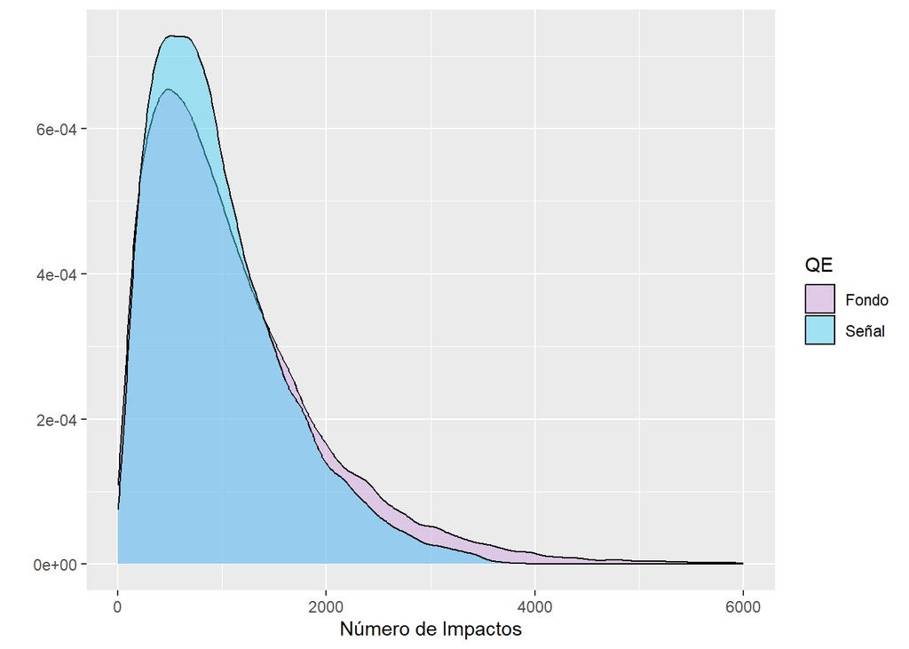

```r
ggplot(data = dat, aes(x = nHits, fill = QE)) +
      geom_density(alpha = 0.5) + scale_fill_manual(values = c("#cda4de66", "#51d1f666")) +
      labs(x="Número de Impactos", y="") + xlim(0,6000)
```

# 3 Análisis Exploratorio 2D

## 3.1 Scatter Plot, todas las variables

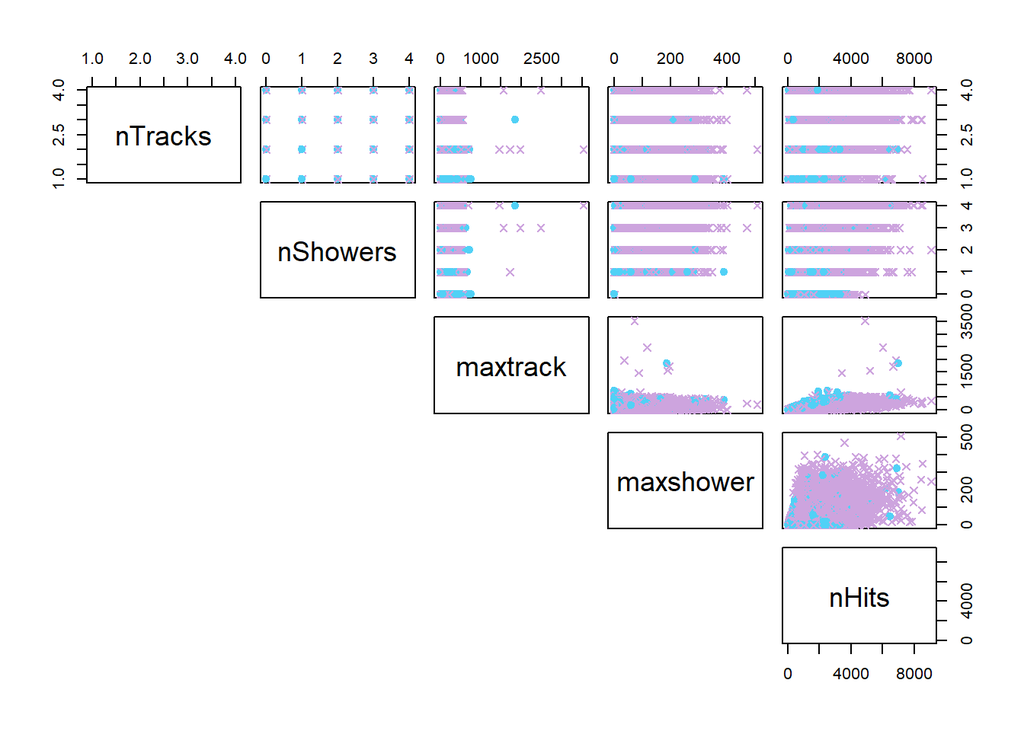

```r
pairs(x = dat[, -6], lower.panel=NULL,
      col = c("#cda4de","#51d1f6")[factor(dat$QE)],
      pch = c(4,19)[factor(dat$QE)])
```

# 4 Comprobación de Hipótesis

## 4.1 Valores Atípicos (Outliers)

**Univariantes**

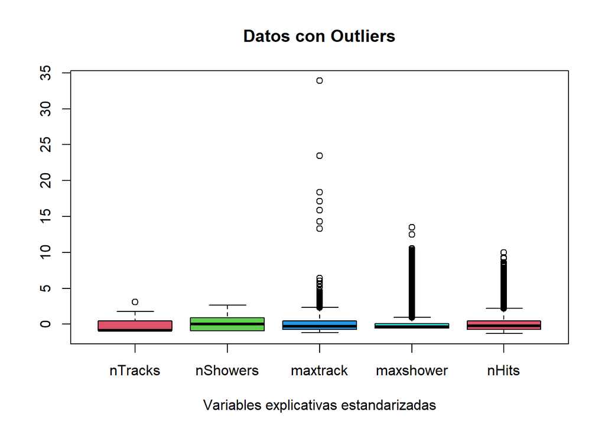

```r
# Boxplots de todas las variables juntas
boxplot(scale(dat[-6]),main="Datos con Outliers",
        xlab="Variables explicativas estandarizadas", ylab="", col=c(2:5))
```

Se observa que la mayoría de outliers de `maxshower` son `Fondo`, lo cual es una información relevante para la clasificación. Se decide por tanto no eliminarlos ni sustituirlos por su media a pesar de los posibles errores que pueda conllevar en las técnicas de clasificación que se utilizarán posteriormente.

Esto no ocurre con la variable `maxtrack`, donde los outliers parecen ser indistintamente `Señal` o `Fondo`. Para esta variable, se pensó en sustituir los outliers por la media, pero ante los malos resultados no se hizo.

## 4.2 Normalidad Univariante

### 4.2.1 Histogramas

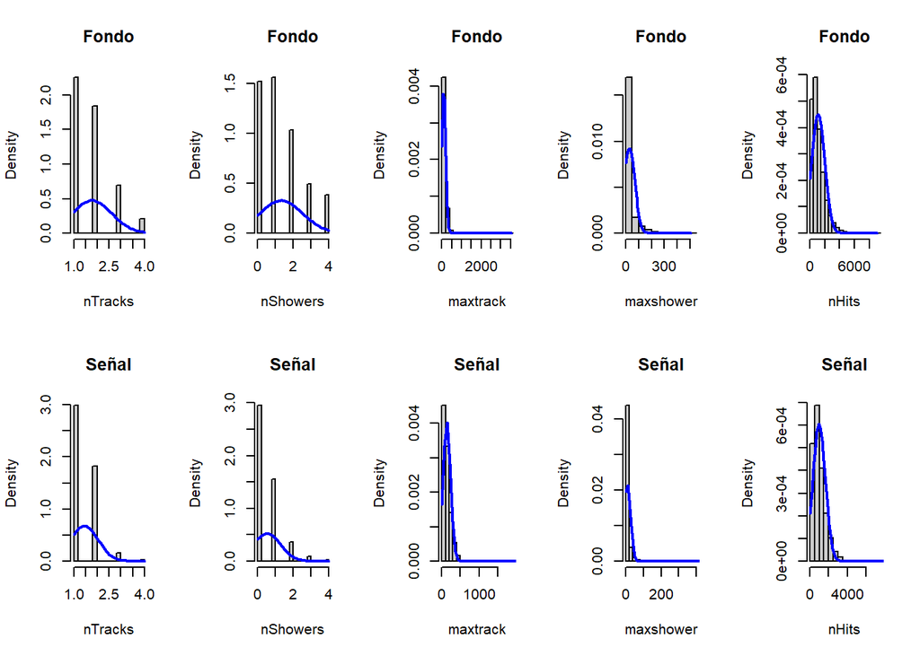

```r
# Histogramas de cada variable separando por QE y añadiendo una normal
par(mfcol = c(2,5))
for (k in c(1:5)) {
  j0 <- names(dat)[k]
  x0 <- seq(min(dat[, k]), max(dat[, k]), le = 50)
  for (i in 1:2) {
    i0 <- levels(as.factor(dat$QE))[i]
    x <- dat[as.factor(dat$QE) == i0, j0]
    hist(x, proba = T, col = grey(0.8), main = paste(i0),xlab = j0)
    lines(x0, dnorm(x0, mean(x), sd(x)), col = "blue", lwd = 2)
  }
}
```

### 4.2.2 Qqplots

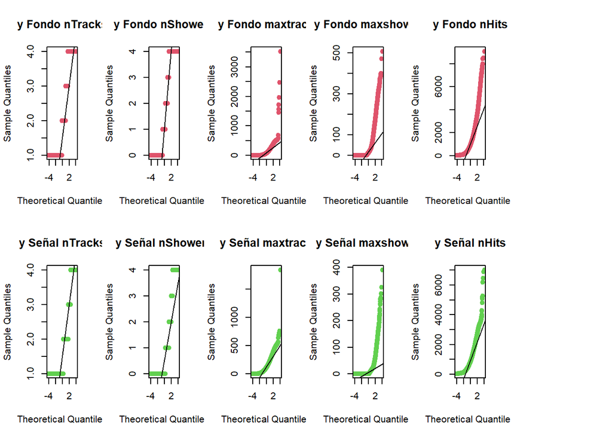

```r
# Qqplots de cada variable separando por QE
par(mfcol=c(2,6))
for (k in c(1:5)) {
  j0 <- names(dat)[k]
  x0 <- seq(min(dat[, k]), max(dat[, k]), le = 50)
  for (i in 1:2) {
    i0 <- levels(as.factor(dat$QE))[i]
    x <- dat[as.factor(dat$QE) == i0, j0]
    qqnorm(x, main = paste("y", i0, j0), pch = 19, col = i + 1)
    qqline(x)
  }
}
```

### 4.2.3 Test Normalidad Univariante (Shapiro-Wilks)

```r
set.seed(2024)

# Se toman solo 35000 observaciones de datos_tidy para poder utilizar shapiro.test()
datos_tidy <- melt(dat, value.name = "value")
datos_tidy <- datos_tidy[sample(1:nrow(datos_tidy),35000),]

# cambiar variable a sample de 5000
resultados_shapiro <- aggregate(value ~ QE + variable, data = datos_tidy,
                               FUN = function(x) shapiro.test(x)$p.value)
print(resultados_shapiro)
```

```
##       QE  variable        value
## 1  Fondo   nTracks 2.467932e-58
## 2  Señal   nTracks 8.045832e-60
## 3  Fondo  nShowers 9.095232e-51
## 4  Señal  nShowers 1.360190e-58
## 5  Fondo  maxtrack 4.924334e-53
## 6  Señal  maxtrack 3.009611e-37
## 7  Fondo maxshower 8.569311e-70
## 8  Señal maxshower 1.389403e-67
## 9  Fondo     nHits 4.839152e-51
## 10 Señal     nHits 3.225140e-38
```

Este resultado (no del todo preciso) refleja una ausencia de normalidad univariante (p-valor<0.05)

## 4.3 Normalidad Multivariante

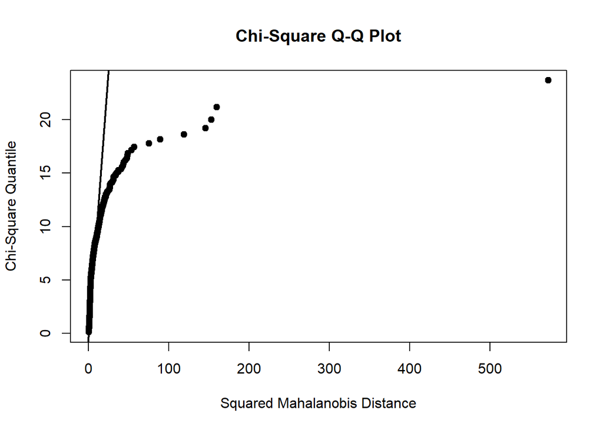

```r
# Royston multivariate normality test (solo 2000 obs. de dat)
royston_test <- mvn(data = dat[1:2000,-6], mvnTest = "royston", multivariatePlot = "qq")
```

```r
royston_test$multivariateNormality
```

| Test | H | p value | MVN |
| --- | --- | --- | --- |
| Royston | 986.6187 | 3.293655e-211 | NO |

```r
# Henze-Zirkler multivariate normality test (solo 5000 obs. de dat)
hz_test <- mvn(data = dat[1:5000,-6], mvnTest = "hz")
hz_test$multivariateNormality
```

| Test | HZ | p value | MVN |
| --- | --- | --- | --- |
| Henze-Zirkler | 114.9113 | 0 | NO |

## 4.4 Ausencia de Multicolinealidad

```r
# Correlación a nivel de la muestra

# Matriz de correlación
cor(dat[-6])
```

```
##              nTracks    nShowers    maxtrack   maxshower     nHits
## nTracks   1.00000000 0.055906139 0.089558460 0.072518469 0.2741202
## nShowers  0.05590614 1.000000000 0.006607904 0.557807383 0.3127155
## maxtrack  0.08955846 0.006607904 1.000000000 0.004709356 0.8018111
## maxshower 0.07251847 0.557807383 0.004709356 1.000000000 0.3896314
## nHits     0.27412019 0.312715454 0.801811054 0.389631402 1.0000000
```

```r
# Determinante
sprintf("Determinante de la matriz de correlación: %f", det(cor(dat[-6])))
```

```
## [1] "Determinante de la matriz de correlación: 0.112603"
```

```r
# Correlación a nivel poblacional

# Test de Esfericidad de Bartlett
cortest.bartlett(cor(scale(dat[-6])))
```

```
## $chisq
## [1] 210.745
##
## $p.value
## [1] 9.218238e-40
##
## $df
## [1] 10
```

Ambos métodos reflejan una importante correlación entre los datos.

## 4.5 Homocedasticidad

```r
boxM(data = dat[, 1:5], grouping = dat[,6])
```

```
##
##  Box's M-test for Homogeneity of Covariance Matrices
##
## data:  dat[, 1:5]
## Chi-Sq (approx.) = 50240, df = 15, p-value < 2.2e-16
```

No puede asumirse la homogeneidad de las matrices de covarianza (p-valor<0.05)

## 4.6 Medias poblacionales distintas

```r
# Univariante
#t.test(nTracks ~ QE, data = dat)
#t.test(nShowers ~ QE, data = dat)
#t.test(maxtrack ~ QE, data = dat)
#t.test(maxshower ~ QE, data = dat)
#t.test(nHits ~ QE, data = dat)

# Multivariante
HotellingsT2(dat.QE$Señal[,-6],dat.QE$Fondo[,-6])
```

```
##
##  Hotelling's two sample T2-test
##
## data:  dat.QE$Señal[, -6] and dat.QE$Fondo[, -6]
## T.2 = 3615.8, df1 = 5, df2 = 71101, p-value < 2.2e-16
## alternative hypothesis: true location difference is not equal to c(0,0,0,0,0)
```

# 5 Técnicas Multivariantes

## 5.1 Partición de los Datos

```r
# Índice de Entrenamiento ("Training Ids") para hacer una Partición de los Datos
# Se recodifican los niveles "Señal" y "Fondo a 1 y 0
set.seed(2001)
t.ids <- createDataPartition(dat$QE, p = 0.8, list = F)

train.set <- dat[t.ids,] %>%
         mutate(QE = recode(QE,"Fondo" = 0, "Señal" = 1))
test.set <- dat[-t.ids,] %>%
         mutate(QE = recode(QE,"Fondo" = 0, "Señal" = 1))

# Función que devuelve la matriz de confusión con ("Señal","Señal") en la 1ª casilla
# m es la matriz de confusión con ("Fondo","Fondo") en la 1ª casilla
c.matrix <- function(m){
  colnames(m) <- c(colnames(m)[2],colnames(m)[1])
  rownames(m) <- c(rownames(m)[2],rownames(m)[1])
  m[1:4] <- c(m[4],m[3],m[2],m[1])
  return(m)
}

# Función que devuelve medidas del rendimiento de un clasificador
# m es la matriz de confusión con ("Señal","Señal") en la 1ª casilla
rend <- function(m){
  TPR <- m[1]/(m[1]+m[3])
  TNR <- m[4]/(m[4]+m[2])
  PPV <- m[1]/(m[1]+m[2])
  NPV <- m[4]/(m[4]+m[3])
  effpur <- TPR*PPV
  ACC <- (m[1]+m[4])/sum(m)
  prevalencia <- (m[1]+m[3])/sum(m)

  return(c(eficiencia=TPR,especificidad=TNR,pureza=PPV,
              VPredNeg=NPV,effpur=effpur,exactitud=ACC,
              prevalencia=prevalencia))
}
```

## 5.2 Regresión Logística

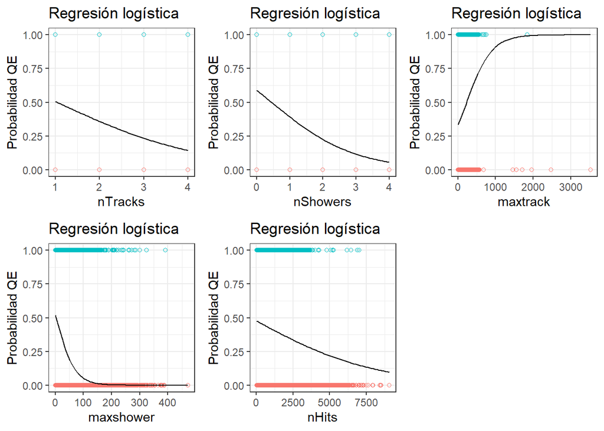

```r
plot.lr <- function(var,nombre){
  # Ajuste de un modelo logístico.
  modelo_logistico <- glm(QE ~ var, data = train.set, family = "binomial")

  # Representación gráfica del modelo.
  ggplot(data = train.set, aes(x = var, y = QE)) +
  geom_point(aes(color = as.factor(QE)), shape = 1) +
  stat_function(fun = function(x){predict(modelo_logistico,
               newdata = data.frame(var = x),type = "response")}) +
  theme_bw() +labs(title = "Regresión logística",y = "Probabilidad QE",
                   x = nombre) +
  theme(legend.position = "none")
}

p1 <- plot.lr(train.set$nTracks,"nTracks")
p2 <- plot.lr(train.set$nShowers,"nShowers")
p3 <- plot.lr(train.set$maxtrack,"maxtrack")
p4 <- plot.lr(train.set$maxshower,"maxshower")
p5 <- plot.lr(train.set$nHits,"nHits")

ggarrange(p1,p2,p3,p4,p5, nrow = 2, ncol=3)
```

```r
# Se entrena el modelo
modelo.lr <- glm(QE ~ ., data = train.set, family = "binomial")
summary(modelo.lr)
```

```
##
## Call:
## glm(formula = QE ~ ., family = "binomial", data = train.set)
##
## Coefficients:
##               Estimate Std. Error z value Pr(>|z|)
## (Intercept)  9.096e-01  2.778e-02  32.741  < 2e-16 ***
## nTracks     -3.648e-01  1.578e-02 -23.125  < 2e-16 ***
## nShowers    -5.844e-01  1.358e-02 -43.030  < 2e-16 ***
## maxtrack     2.262e-02  3.729e-04  60.664  < 2e-16 ***
## maxshower    4.269e-03  5.437e-04   7.851 4.12e-15 ***
## nHits       -2.888e-03  5.572e-05 -51.828  < 2e-16 ***
## ---
## Signif. codes:  0 '***' 0.001 '**' 0.01 '*' 0.05 '.' 0.1 ' ' 1
##
## (Dispersion parameter for binomial family taken to be 1)
##
##     Null deviance: 77247  on 56885  degrees of freedom
## Residual deviance: 61082  on 56880  degrees of freedom
## AIC: 61094
##
## Number of Fisher Scoring iterations: 6
```

```r
cat("-------------------------------------------------\n")
# odds ratios y 95% CI ( media +- 1.96*s/sqrt(n), con n=1 )
exp(cbind(OR = coef(modelo.lr), confint.default(modelo.lr)))
```

```
##                    OR     2.5 %    97.5 %
## (Intercept) 2.4832335 2.3516379 2.6221931
## nTracks     0.6943291 0.6731890 0.7161330
## nShowers    0.5574671 0.5428249 0.5725043
## maxtrack    1.0228798 1.0221325 1.0236277
## maxshower   1.0042780 1.0032084 1.0053488
## nHits       0.9971164 0.9970075 0.9972253
```

Aplicando el método de selección paso a paso (stepwise), se confirma el uso de las variables previamente seleccionadas:

```r
# Método step-wise
step(modelo.lr,direction = "both")
```

```
## Start:  AIC=61094.39
## QE ~ nTracks + nShowers + maxtrack + maxshower + nHits
##
##             Df Deviance   AIC
## <none>            61082 61094
## - maxshower  1    61150 61160
## - nTracks    1    61604 61614
## - nShowers   1    63061 63071
## - nHits      1    64455 64465
## - maxtrack   1    65867 65877
```

```
##
## Call:  glm(formula = QE ~ nTracks + nShowers + maxtrack + maxshower +
##     nHits, family = "binomial", data = train.set)
##
## Coefficients:
## (Intercept)      nTracks     nShowers     maxtrack    maxshower        nHits
##    0.909562    -0.364809    -0.584352     0.022622     0.004269    -0.002888
##
## Degrees of Freedom: 56885 Total (i.e. Null);  56880 Residual
## Null Deviance:       77250
## Residual Deviance: 61080     AIC: 61090
```

```r
# Curva ROC (Método 1)
par(pty = "s") # Para que la gráfica sea cuadrada (square)

aux <- predict(modelo.lr, newdata = train.set,type = "response")
r <- multiclass.roc(train.set$QE,aux,percent=T)
```

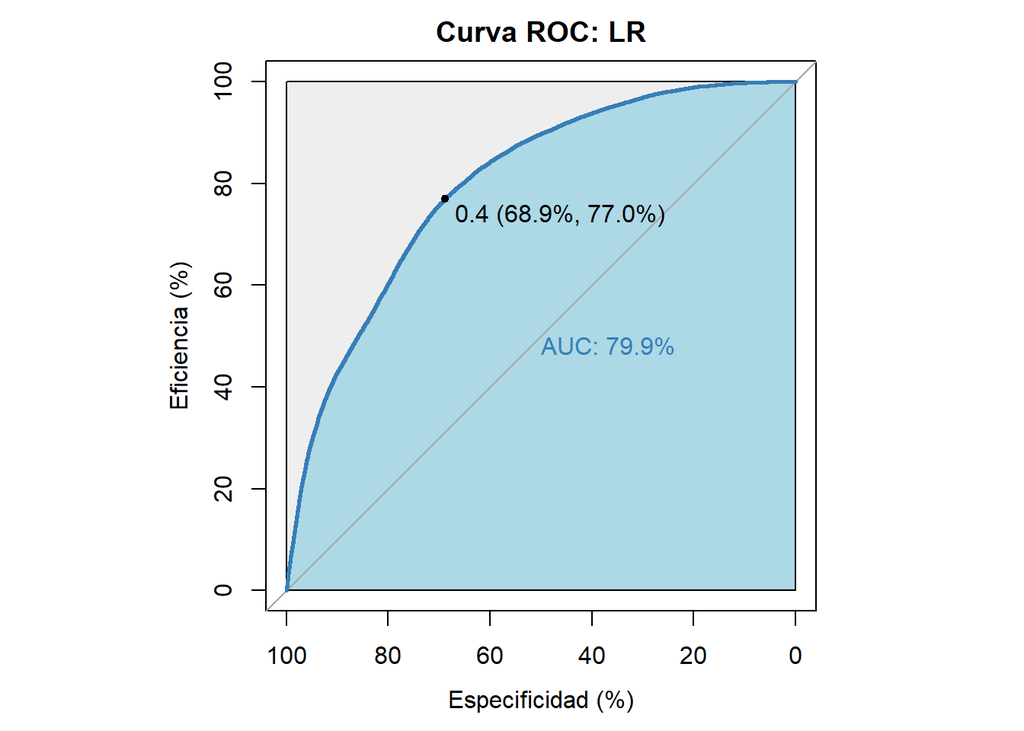

```r
r1 <- r$rocs[[1]]
plot.roc(r1,print.auc = T,auc.polygon = T,max.auc.polygon = T,
         auc.polygon.col = "lightblue",print.thres = T,main = "Curva ROC: LR",
         col = "#377eb8", lwd = 2.5, xlab = "Especificidad (%)",
         ylab = "Eficiencia (%)")
```

```r
# Mejor punto de corte
sprintf("Mejor punto de corte: %1.4f",coords(r1, "best",transpose=F)$threshold)
```

```
## [1] "Mejor punto de corte: 0.4341"
```

```r
# Curva ROC (Método 2)
#par(pty = "s") # square
#roc(train.set$QE, modelo.lr$fitted.values, plot = TRUE, legacy.axes = TRUE,
#    percent = TRUE, xlab = "Porcentaje Falsos positivos",
#    ylab = "Porcentaje verdaderos positivos", col = "#377eb8", lwd = 2,
#    print.auc = TRUE)
```

Se usa el punto de corte óptimo obtenido con la curva ROC.

```r
# Se usa con test.set y se crea la matriz de confusión
pred <- predict(modelo.lr, newdata = test.set,type = "response")
pred <- ifelse(pred > 0.4341, yes = 1, no = 0)

print("Matriz de confusión:")
```

```
## [1] "Matriz de confusión:"
```

```r
cm <- table(test.set$QE, pred, dnn = c("Valor Real", "Valor Predicho"))
cm <- c.matrix(cm); cm
```

```
##           Valor Predicho
## Valor Real    1    0
##          1 4621 1295
##          0 2567 5738
```

```r
cat("-------------------------------------------------\n")
# Compruebo que tenga el mismo número de datos que test.set
#print("¿Hay tantas observaciones como nrow(test.set)?")
#sum(cm)==nrow(test.set)
#cat("-------------------------------------------------\n")

# Medidas del rendimiento de un clasificador
rend(cm)
```

```
##    eficiencia especificidad        pureza      VPredNeg        effpur
##     0.7811021     0.6909091     0.6428770     0.8158681     0.5021526
##     exactitud   prevalencia
##     0.7284298     0.4160045
```

```r
# Método 2
#confusionMatrix(data = as.factor(pred), reference = as.factor(test.set$QE),positive = "1")
```

Usando 0.5 como punto de corte:

```r
# Se usa con test.set y se crea la matriz de confusión
pred <- predict(modelo.lr, newdata = test.set,type = "response")
pred <- ifelse(pred > 0.5, yes = 1, no = 0)

print("Matriz de confusión:")
```

```
## [1] "Matriz de confusión:"
```

```r
cm <- table(test.set$QE, pred, dnn = c("Valor Real", "Valor Predicho"))
cm <- c.matrix(cm); cm
```

```
##           Valor Predicho
## Valor Real    1    0
##          1 3951 1965
##          0 1921 6384
```

```r
cat("-------------------------------------------------\n")
# Compruebo que tenga el mismo número de datos que test.set
#print("¿Hay tantas observaciones como nrow(test.set)?")
#sum(cm)==nrow(test.set)
#cat("-------------------------------------------------\n")

# Medidas del rendimiento de un clasificador
rend(cm)
```

```
##    eficiencia especificidad        pureza      VPredNeg        effpur
##     0.6678499     0.7686936     0.6728542     0.7646425     0.4493656
##     exactitud   prevalencia
##     0.7267421     0.4160045
```

## 5.3 Análisis Discriminante Lineal

```r
# Se entrena el modelo
modelo.lda <- lda(QE ~ ., data = train.set)
coef(modelo.lda)
```

```
##                     LD1
## nTracks   -0.4996646104
## nShowers  -0.5817046534
## maxtrack   0.0094107839
## maxshower  0.0006409520
## nHits     -0.0008601022
```

```r
# Curva ROC
par(pty = "s") # Para que la gráfica sea cuadrada (square)

aux <- predict(modelo.lda, newdata = train.set)
r <- multiclass.roc(train.set$QE,as.numeric(aux$class),percent=T)
```

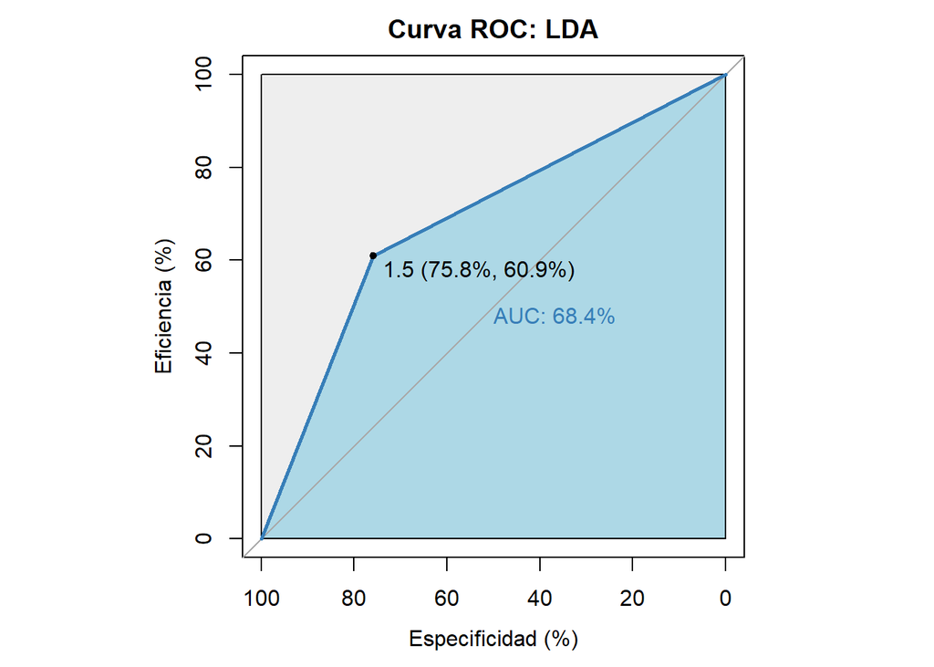

```r
r1 <- r$rocs[[1]]
plot.roc(r1,print.auc = T,auc.polygon = T,max.auc.polygon = T,
         auc.polygon.col = "lightblue",print.thres = T,main = "Curva ROC: LDA",
         col = "#377eb8", lwd = 2.5, xlab = "Especificidad (%)",
         ylab = "Eficiencia (%)")
```

```r
# Mejor punto de corte
sprintf("Mejor punto de corte: %1.4f",coords(r1, "best",transpose=F)$threshold)
```

```
## [1] "Mejor punto de corte: 1.5000"
```

Recordar que lda implementa el método bayesiano, así que asigna como señal/fondo a aquel suceso con mayor probabilidad a posteriori. No incluyo entonces el punto de corte óptimo.

```r
# Se usa con test.set y se crea la matriz de confusión
pred <- predict(object = modelo.lda, newdata = test.set)
cm <- confusionmatrix(test.set$QE, pred$class)
cm <- c.matrix(cm); cm
```

```
##   new 1 new 0
## 1  3606  2310
## 0  1978  6327
```

```r
cat("-------------------------------------------------\n")
# Compruebo que tenga el mismo número de datos que test.set
#print("¿Hay tantas observaciones como nrow(test.set)?")
#sum(cm)==nrow(test.set)
#cat("-------------------------------------------------\n")

# Medidas del rendimiento de un clasificador (Método 1)
rend(cm)
```

```
##    eficiencia especificidad        pureza      VPredNeg        effpur
##     0.6095335     0.7618302     0.6457736     0.7325460     0.3936206
##     exactitud   prevalencia
##     0.6984741     0.4160045
```

```r
# Método 2
#confusionMatrix(data = pred$class, reference = as.factor(test.set$QE),positive = "1")

# Método 3
#caret::confusionMatrix(table(pred$class, test.set$QE), positive = "1")
```

## 5.4 Análisis Discriminante Cuadrático

```r
# Se entrena el modelo (no da los coeficientes)
modelo.qda <- qda(QE ~ ., data = train.set)
```

```r
# Curva ROC
par(pty = "s") # Para que la gráfica sea cuadrada (square)

aux <- predict(modelo.qda, newdata = train.set)
r <- multiclass.roc(train.set$QE,as.numeric(aux$class),percent=T)
```

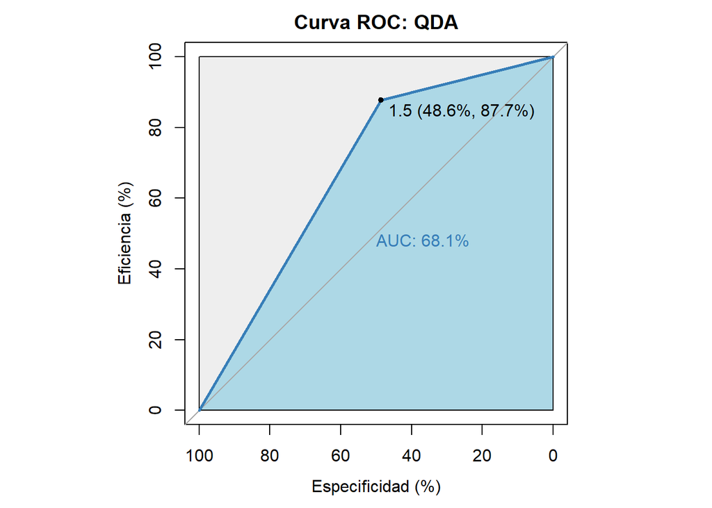

```r
r1 <- r$rocs[[1]]
plot.roc(r1,print.auc = T,auc.polygon = T,max.auc.polygon = T,
         auc.polygon.col = "lightblue",print.thres = T,main = "Curva ROC: QDA",
         col = "#377eb8", lwd = 2.5, xlab = "Especificidad (%)",
         ylab = "Eficiencia (%)")
```

```r
# Mejor punto de corte
sprintf("Mejor punto de corte: %1.4f",coords(r1, "best",transpose=F)$threshold)
```

```
## [1] "Mejor punto de corte: 1.5000"
```

No incluyo el punto de corte óptimo, como en el caso del LDA.

```r
# Se usa con test.set y se crea la matriz de confusión
pred <- predict(object = modelo.qda, newdata = test.set)
cm <- confusionmatrix(test.set$QE, pred$class)
cm <- c.matrix(cm); cm
```

```
##   new 1 new 0
## 1  5273   643
## 0  4276  4029
```

```r
cat("-------------------------------------------------\n")
# Compruebo que tenga el mismo número de datos que test.set
#print("¿Hay tantas observaciones como nrow(test.set)?")
#sum(cm)==nrow(test.set)
#cat("-------------------------------------------------\n")

# Medidas del rendimiento de un clasificador
rend(cm)
```

```
##    eficiencia especificidad        pureza      VPredNeg        effpur
##     0.8913117     0.4851294     0.5522044     0.8623716     0.4921863
##     exactitud   prevalencia
##     0.6541031     0.4160045
```

## 5.5 Naïve Bayes

### 5.5.1 Sin Laplace Smoothing

```r
train.set.f <- within(train.set, QE <- as.factor(QE))
test.set.f <- within(test.set, QE <- as.factor(QE))

# Se entrena el modelo
modelo.nb <- naive_bayes(QE ~ ., data=train.set.f) # Sin Laplace Smoothing (laplace = 1)
```

```r
# Curva ROC
par(pty = "s") # Para que la gráfica sea cuadrada (square)

aux <- predict(modelo.nb, newdata = train.set.f)
r <- multiclass.roc(train.set.f$QE,as.numeric(aux),percent=T)
```

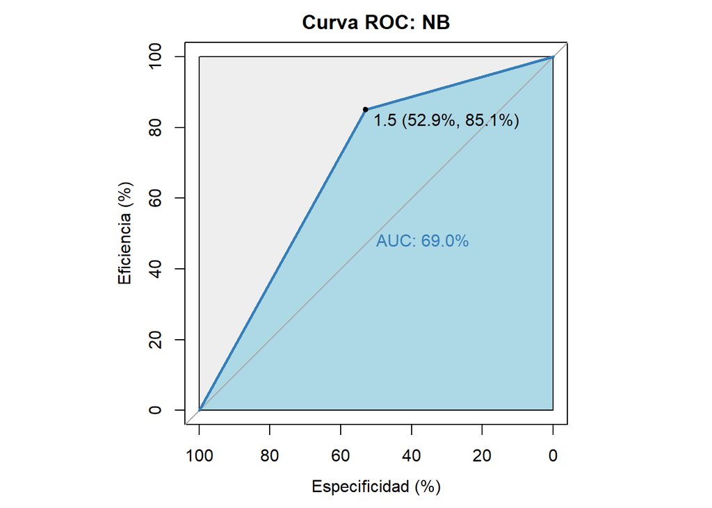

```r
r1 <- r$rocs[[1]]
plot.roc(r1,print.auc = T,auc.polygon = T,max.auc.polygon = T,
         auc.polygon.col = "lightblue",print.thres = T,main = "Curva ROC: NB",
         col = "#377eb8", lwd = 2.5, xlab = "Especificidad (%)",
         ylab = "Eficiencia (%)")
```

```r
# Mejor punto de corte
sprintf("Mejor punto de corte: %1.4f",coords(r1, "best",transpose=F)$threshold)
```

```
## [1] "Mejor punto de corte: 1.5000"
```

```r
# Se usa con test.set y se crea la matriz de confusión
pred <- predict(object = modelo.nb, newdata = test.set.f)
cm <- confusionmatrix(test.set.f$QE, pred)
cm <- c.matrix(cm); cm
```

```
##   new 1 new 0
## 1  5094   822
## 0  3887  4418
```

```r
cat("-------------------------------------------------\n")
# Compruebo que tenga el mismo número de datos que test.set
#print("¿Hay tantas observaciones como nrow(test.set)?")
#sum(cm)==nrow(test.set)
#cat("-------------------------------------------------\n")

# Medidas del rendimiento de un clasificador
rend(cm)
```

```
##    eficiencia especificidad        pureza      VPredNeg        effpur
##     0.8610548     0.5319687     0.5671974     0.8431298     0.4883880
##     exactitud   prevalencia
##     0.6688700     0.4160045
```

```r
# Método 2
#confusionMatrix(data = pred, reference = test.set.f$QE, positive = "1")
```

### 5.5.2 Con Laplace Smoothing

```r
train.set.f <- within(train.set, QE <- as.factor(QE))
test.set.f <- within(test.set, QE <- as.factor(QE))

# Se entrena el modelo
modelo.nb2 <- naive_bayes(QE ~ ., data=train.set.f, laplace = 1) # Con Laplace Smoothing (laplace = 1)
```

```r
# Curva ROC
par(pty = "s") # Para que la gráfica sea cuadrada (square)

aux <- predict(modelo.nb2, newdata = train.set.f)
r <- multiclass.roc(train.set.f$QE,as.numeric(aux),percent=T)
```

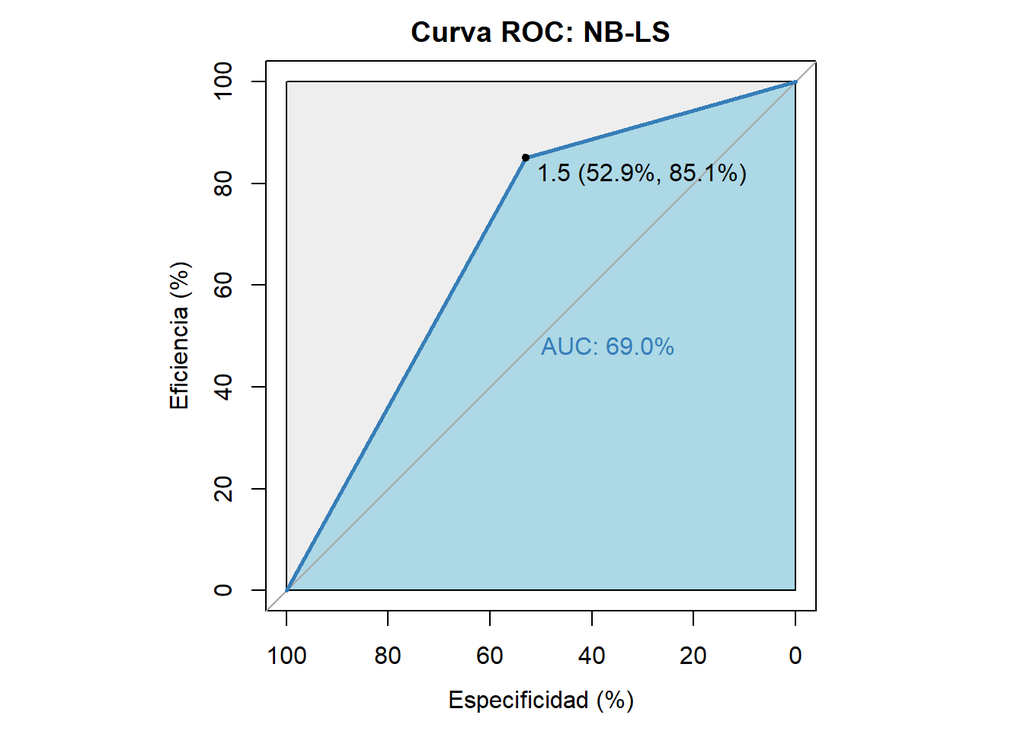

```r
r1 <- r$rocs[[1]]
plot.roc(r1,print.auc = T,auc.polygon = T,max.auc.polygon = T,
         auc.polygon.col = "lightblue",print.thres = T,main = "Curva ROC: NB-LS",
         col = "#377eb8", lwd = 2.5, xlab = "Especificidad (%)",
         ylab = "Eficiencia (%)")
```

```r
# Mejor punto de corte
sprintf("Mejor punto de corte: %1.4f",coords(r1, "best",transpose=F)$threshold)
```

```
## [1] "Mejor punto de corte: 1.5000"
```

```r
# Se usa con test.set y se crea la matriz de confusión
pred <- predict(object = modelo.nb2, newdata = test.set.f)
cm <- confusionmatrix(test.set.f$QE, pred)
cm <- c.matrix(cm); cm
```

```
##   new 1 new 0
## 1  5094   822
## 0  3887  4418
```

```r
cat("-------------------------------------------------\n")
# Compruebo que tenga el mismo número de datos que test.set
#print("¿Hay tantas observaciones como nrow(test.set)?")
#sum(cm)==nrow(test.set)
#cat("-------------------------------------------------\n")

# Medidas del rendimiento de un clasificador
rend(cm)
```

```
##    eficiencia especificidad        pureza      VPredNeg        effpur
##     0.8610548     0.5319687     0.5671974     0.8431298     0.4883880
##     exactitud   prevalencia
##     0.6688700     0.4160045
```

```r
# Método 2
#confusionMatrix(data = pred, reference = test.set.f$QE, positive = "1")
```

Se observa que el resultado es análogo utilizando Laplace Smoothing o no.

## 5.6 k Nearest Neighbors

```r
# Se normalizan las variables
train.set.n <- as.data.frame(cbind(scale(train.set[-6]),train.set$QE))
test.set.n <- as.data.frame(cbind(scale(test.set[-6]),test.set$QE))
```

### 5.6.1 Selección del hiperparámetro k

```r
# Área bajo la curva ROC
par(pty = "s") # Para que la gráfica sea cuadrada (square)

aux <- pred <- knn(train.set.n[,-6],train.set.n[,-6], train.set.n[,6], k=1)
r <- multiclass.roc(train.set.n[[6]],as.numeric(aux),percent=T)
r1 <- r$rocs[[1]]
auc(r1)
```

```
## Area under the curve: 100%
```

```r
aux <- pred <- knn(train.set.n[,-6],train.set.n[,-6], train.set.n[,6], k=3)
r <- multiclass.roc(train.set.n[[6]],as.numeric(aux),percent=T)
r1 <- r$rocs[[1]]
auc(r1)
```

```
## Area under the curve: 83.25%
```

```r
aux <- pred <- knn(train.set.n[,-6],train.set.n[,-6], train.set.n[,6], k=5)
r <- multiclass.roc(train.set.n[[6]],as.numeric(aux),percent=T)
r1 <- r$rocs[[1]]
auc(r1)
```

```
## Area under the curve: 80.05%
```

```r
aux <- pred <- knn(train.set.n[,-6],train.set.n[,-6], train.set.n[,6], k=7)
r <- multiclass.roc(train.set.n[[6]],as.numeric(aux),percent=T)
r1 <- r$rocs[[1]]
auc(r1)
```

```
## Area under the curve: 78.73%
```

```r
aux <- pred <- knn(train.set.n[,-6],train.set.n[,-6], train.set.n[,6], k=9)
r <- multiclass.roc(train.set.n[[6]],as.numeric(aux),percent=T)
r1 <- r$rocs[[1]]
auc(r1)
```

```
## Area under the curve: 77.97%
```

```r
aux <- pred <- knn(train.set.n[,-6],train.set.n[,-6], train.set.n[,6], k=11)
r <- multiclass.roc(train.set.n[[6]],as.numeric(aux),percent=T)
r1 <- r$rocs[[1]]
auc(r1)
```

```
## Area under the curve: 77.66%
```

```r
aux <- pred <- knn(train.set.n[,-6],train.set.n[,-6], train.set.n[,6], k=13)
r <- multiclass.roc(train.set.n[[6]],as.numeric(aux),percent=T)
r1 <- r$rocs[[1]]
auc(r1)
```

```
## Area under the curve: 77.34%
```

```r
aux <- pred <- knn(train.set.n[,-6],train.set.n[,-6], train.set.n[,6], k=15)
r <- multiclass.roc(train.set.n[[6]],as.numeric(aux),percent=T)
r1 <- r$rocs[[1]]
auc(r1)
```

```
## Area under the curve: 76.96%
```

```r
aux <- pred <- knn(train.set.n[,-6],train.set.n[,-6], train.set.n[,6], k=17)
r <- multiclass.roc(train.set.n[[6]],as.numeric(aux),percent=T)
r1 <- r$rocs[[1]]
auc(r1)
```

```
## Area under the curve: 76.86%
```

```r
aux <- pred <- knn(train.set.n[,-6],train.set.n[,-6], train.set.n[,6], k=19)
r <- multiclass.roc(train.set.n[[6]],as.numeric(aux),percent=T)
r1 <- r$rocs[[1]]
auc(r1)
```

```
## Area under the curve: 76.68%
```

```r
aux <- pred <- knn(train.set.n[,-6],train.set.n[,-6], train.set.n[,6], k=21)
r <- multiclass.roc(train.set.n[[6]],as.numeric(aux),percent=T)
r1 <- r$rocs[[1]]
auc(r1)
```

```
## Area under the curve: 76.6%
```

```r
# Validación del Modelo
pred <- knn(train.set.n[,-6],test.set.n[,-6], train.set.n[,6], k=1)
cm <- confusionmatrix(test.set.n[[6]], pred)
cm <- c.matrix(cm)
rend(cm)
```

```
##    eficiencia especificidad        pureza      VPredNeg        effpur
##     0.6090264     0.7299217     0.6163189     0.7238209     0.3753544
##     exactitud   prevalencia
##     0.6796287     0.4160045
```

```r
pred <- knn(train.set.n[,-6],test.set.n[,-6], train.set.n[,6], k=3)
cm <- confusionmatrix(test.set.n[[6]], pred)
cm <- c.matrix(cm)
rend(cm)
```

```
##    eficiencia especificidad        pureza      VPredNeg        effpur
##     0.6440162     0.7723058     0.6683038     0.7528169     0.4303985
##     exactitud   prevalencia
##     0.7189368     0.4160045
```

```r
pred <- knn(train.set.n[,-6],test.set.n[,-6], train.set.n[,6], k=5)
cm <- confusionmatrix(test.set.n[[6]], pred)
cm <- c.matrix(cm)
rend(cm)
```

```
##    eficiencia especificidad        pureza      VPredNeg        effpur
##     0.6592292     0.7873570     0.6883163     0.7643483     0.4537582
##     exactitud   prevalencia
##     0.7340553     0.4160045
```

```r
pred <- knn(train.set.n[,-6],test.set.n[,-6], train.set.n[,6], k=7)
cm <- confusionmatrix(test.set.n[[6]], pred)
cm <- c.matrix(cm)
rend(cm)
```

```
##    eficiencia especificidad        pureza      VPredNeg        effpur
##     0.6683570     0.7932571     0.6972315     0.7705263     0.4659996
##     exactitud   prevalencia
##     0.7412981     0.4160045
```

```r
pred <- knn(train.set.n[,-6],test.set.n[,-6], train.set.n[,6], k=9)
cm <- confusionmatrix(test.set.n[[6]], pred)
cm <- c.matrix(cm)
rend(cm)
```

```
##    eficiencia especificidad        pureza      VPredNeg        effpur
##     0.6746112     0.7961469     0.7021464     0.7745110     0.4736758
##     exactitud   prevalencia
##     0.7455875     0.4160045
```

```r
pred <- knn(train.set.n[,-6],test.set.n[,-6], train.set.n[,6], k=11)
cm <- confusionmatrix(test.set.n[[6]], pred)
cm <- c.matrix(cm)
rend(cm)
```

```
##    eficiencia especificidad        pureza      VPredNeg        effpur
##     0.6735970     0.8010837     0.7069363     0.7750466     0.4761902
##     exactitud   prevalencia
##     0.7480487     0.4160045
```

```r
pred <- knn(train.set.n[,-6],test.set.n[,-6], train.set.n[,6], k=13)
cm <- confusionmatrix(test.set.n[[6]], pred)
cm <- c.matrix(cm)
rend(cm)
```

```
##    eficiencia especificidad        pureza      VPredNeg        effpur
##     0.6751183     0.8015653     0.7079050     0.7759646     0.4779196
##     exactitud   prevalencia
##     0.7489628     0.4160045
```

```r
pred <- knn(train.set.n[,-6],test.set.n[,-6], train.set.n[,6], k=15)
cm <- confusionmatrix(test.set.n[[6]], pred)
cm <- c.matrix(cm)
rend(cm)
```

```
##    eficiencia especificidad        pureza      VPredNeg        effpur
##     0.6774848     0.8043347     0.7115214     0.7778295     0.4820449
##     exactitud   prevalencia
##     0.7515646     0.4160045
```

```r
pred <- knn(train.set.n[,-6],test.set.n[,-6], train.set.n[,6], k=17)
cm <- confusionmatrix(test.set.n[[6]], pred)
cm <- c.matrix(cm)
rend(cm)
```

```
##    eficiencia especificidad        pureza      VPredNeg        effpur
##     0.6791751     0.8059001     0.7136767     0.7790711     0.4847115
##     exactitud   prevalencia
##     0.7531819     0.4160045
```

```r
pred <- knn(train.set.n[,-6],test.set.n[,-6], train.set.n[,6], k=19)
cm <- confusionmatrix(test.set.n[[6]], pred)
cm <- c.matrix(cm)
rend(cm)
```

```
##    eficiencia especificidad        pureza      VPredNeg        effpur
##     0.6849222     0.8084287     0.7180578     0.7826999     0.4918137
##     exactitud   prevalencia
##     0.7570494     0.4160045
```

```r
pred <- knn(train.set.n[,-6],test.set.n[,-6], train.set.n[,6], k=21)
cm <- confusionmatrix(test.set.n[[6]], pred)
cm <- c.matrix(cm)
rend(cm)
```

```
##    eficiencia especificidad        pureza      VPredNeg        effpur
##     0.6857674     0.8096328     0.7195814     0.7834091     0.4934655
##     exactitud   prevalencia
##     0.7581042     0.4160045
```

### 5.6.2 Implementación del algoritmo

```r
# Normalizando las variables

# Se entrena el modelo, se usa con test.set y se crea la matriz de confusión
pred <- knn(train.set.n[,-6],test.set.n[,-6], train.set.n[,6], k=21)
cm <- confusionmatrix(test.set.n[[6]], pred)
cm <- c.matrix(cm); cm
```

```
##   new 1 new 0
## 1  4057  1859
## 0  1581  6724
```

```r
cat("-------------------------------------------------\n")
# Compruebo que tenga el mismo número de datos que test.set
#print("¿Hay tantas observaciones como nrow(test.set)?")
#sum(cm)==nrow(test.set.n)
#cat("-------------------------------------------------\n")

# Medidas del rendimiento de un clasificador (Método 1)
rend(cm)
```

```
##    eficiencia especificidad        pureza      VPredNeg        effpur
##     0.6857674     0.8096328     0.7195814     0.7834091     0.4934655
##     exactitud   prevalencia
##     0.7581042     0.4160045
```

```r
# Método 2
#confusionMatrix(data = pred, reference = as.factor(test.set.n[[7]]),positive = "1")
```

```r
# Curva ROC
par(pty = "s") # Para que la gráfica sea cuadrada (square)

aux <- pred <- knn(train.set.n[,-6],train.set.n[,-6], train.set.n[,6], k=21)
r <- multiclass.roc(train.set.n[[6]],as.numeric(aux),percent=T)
```

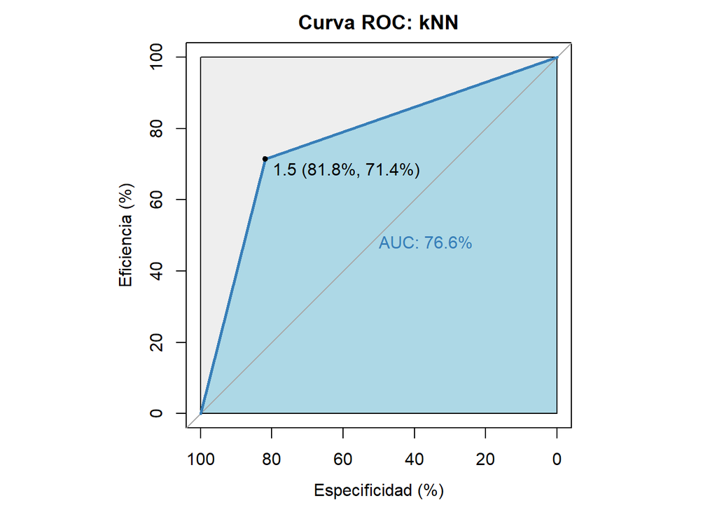

```r
r1 <- r$rocs[[1]]
plot.roc(r1,print.auc = T,auc.polygon = T,max.auc.polygon = T,
         auc.polygon.col = "lightblue",print.thres = T,main = "Curva ROC: kNN",
         col = "#377eb8", lwd = 2.5, xlab = "Especificidad (%)",
         ylab = "Eficiencia (%)")
```

```r
# Mejor punto de corte
sprintf("Mejor punto de corte: %1.4f",coords(r1, "best",transpose=F)$threshold)
```

```
## [1] "Mejor punto de corte: 1.5000"
```

```r
# Sin normalizar las variables

# Se entrena el modelo, se usa con test.set y se crea la matriz de confusión
pred <- knn(train.set[,-6],test.set[,-6], train.set[,6], k=21)
cm <- confusionmatrix(test.set$QE, pred)
cm <- c.matrix(cm); cm
```

```
##   new 1 new 0
## 1  3921  1995
## 0  1784  6521
```

```r
cat("-------------------------------------------------\n")
# Medidas del rendimiento de un clasificador (Método 1)
rend(cm)
```

```
##    eficiencia especificidad        pureza      VPredNeg        effpur
##     0.6627789     0.7851896     0.6872918     0.7657351     0.4555225
##     exactitud   prevalencia
##     0.7342662     0.4160045
```

```r
# Curva ROC
par(pty = "s") # Para que la gráfica sea cuadrada (square)

aux <- pred <- knn(train.set[,-6],train.set[,-6], train.set[,6], k=21)
r <- multiclass.roc(train.set$QE,as.numeric(aux),percent=T)
```

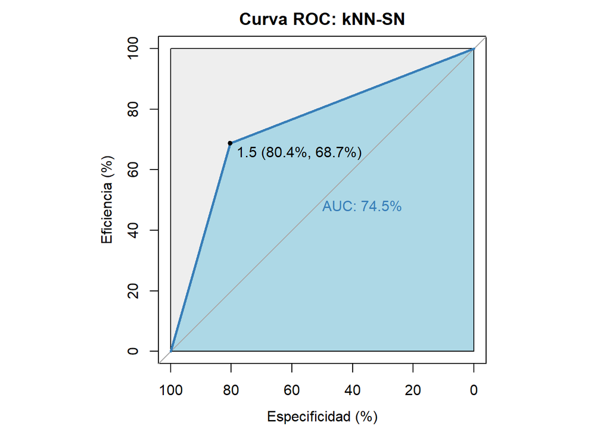

```r
r1 <- r$rocs[[1]]
plot.roc(r1,print.auc = T,auc.polygon = T,max.auc.polygon = T,
         auc.polygon.col = "lightblue",print.thres = T,main = "Curva ROC: kNN-SN",
         col = "#377eb8", lwd = 2.5, xlab = "Especificidad (%)",
         ylab = "Eficiencia (%)")
```

```r
# Mejor punto de corte
sprintf("Mejor punto de corte: %1.4f",coords(r1, "best",transpose=F)$threshold)
```

```
## [1] "Mejor punto de corte: 1.5000"
```